# Ejercicio 4

Lucio Cornejo

2025-05-04

## 1 Pregunta 3: Modelamiento

```r
Decathlon <- read.csv("Decathlon.csv", row.names = 1)
lab <- rownames(Decathlon)
Decathlon
```

```
##             X100m Long.jump Shot.put High.jump X400m X110m.hurdle Discus Pole.vault Javeline X1500m Points
## Sebrle      10.85      7.84    16.36      2.12 48.36        14.05  48.72        5.0    70.52 280.01   8893
## Clay        10.44      7.96    15.23      2.06 49.19        14.13  50.11        4.9    69.71 282.00   8820
## Karpov      10.50      7.81    15.93      2.09 46.81        13.97  51.65        4.6    55.54 278.11   8725
## Macey       10.89      7.47    15.73      2.15 48.97        14.56  48.34        4.4    58.46 265.42   8414
## Warners     10.62      7.74    14.48      1.97 47.97        14.01  43.73        4.9    55.39 278.05   8343
## Zsivoczky   10.91      7.14    15.31      2.12 49.40        14.95  45.62        4.7    63.45 269.54   8287
## Hernu       10.97      7.19    14.65      2.03 48.73        14.25  44.72        4.8    57.76 264.35   8237
## Nool        10.80      7.53    14.26      1.88 48.81        14.80  42.05        5.4    61.33 276.33   8235
## Bernard     10.69      7.48    14.80      2.12 49.13        14.17  44.75        4.4    55.27 276.31   8225
## Schwarzl    10.98      7.49    14.01      1.94 49.76        14.25  42.43        5.1    56.32 273.56   8102
## Pogorelov   10.95      7.31    15.10      2.06 50.79        14.21  44.60        5.0    53.45 287.63   8084
## Schoenbeck  10.90      7.30    14.77      1.88 50.30        14.34  44.41        5.0    60.89 278.82   8077
## Barras      11.14      6.99    14.91      1.94 49.41        14.37  44.83        4.6    64.55 267.09   8067
## Smith       10.85      6.81    15.24      1.91 49.27        14.01  49.02        4.2    61.52 272.74   8023
## Averyanov   10.55      7.34    14.44      1.94 49.72        14.39  39.88        4.8    54.51 271.02   8021
## Ojaniemi    10.68      7.50    14.97      1.94 49.12        15.01  40.35        4.6    59.26 275.71   8006
## Smirnov     10.89      7.07    13.88      1.94 49.11        14.77  42.47        4.7    60.88 263.31   7993
## Qi          11.06      7.34    13.55      1.97 49.65        14.78  45.13        4.5    60.79 272.63   7934
## Drews       10.87      7.38    13.07      1.88 48.51        14.01  40.11        5.0    51.53 274.21   7926
## Parkhomenko 11.14      6.61    15.69      2.03 51.04        14.88  41.90        4.8    65.82 277.94   7918
## Terek       10.92      6.94    15.15      1.94 49.56        15.12  45.62        5.3    50.62 290.36   7893
## Gomez       11.08      7.26    14.57      1.85 48.61        14.41  40.95        4.4    60.71 269.70   7865
## Turi        11.08      6.91    13.62      2.03 51.67        14.26  39.83        4.8    59.34 290.01   7708
## Lorenzo     11.10      7.03    13.22      1.85 49.34        15.38  40.22        4.5    58.36 263.08   7592
## Karlivans   11.33      7.26    13.30      1.97 50.54        14.98  43.34        4.5    52.92 278.67   7583
## Korkizoglou 10.86      7.07    14.81      1.94 51.16        14.96  46.07        4.7    53.05 317.00   7573
## Uldal       11.23      6.99    13.53      1.85 50.95        15.09  43.01        4.5    60.00 281.70   7495
## Casarsa     11.36      6.68    14.92      1.94 53.20        15.39  48.66        4.4    58.62 296.12   7404
```

```r
graficar_modelos <- function(modelo) {
  res <- list()
  res$estimados_observados <- function(mostrar_texto = FALSE) {
    plot(modelo$fitted.values, Decathlon$Points, pch = 20, xlab = "estimados", ylab = "observados")
    abline(0, 1, col = "red")

    if (mostrar_texto) text(modelo$fitted.values, Decathlon$Points,labels=lab,pos=3,offset(0.5));

    points(modelo$fitted.values, modelo$fitted.values, pch = 20, col = "red")
  }

  res$estimados_residuos <- function(mostrar_texto = FALSE) {
    plot(modelo$fitted.values, modelo$residuals, pch = 20, xlab = "estimados", ylab = "residuos")
    abline(0, 0, col = "red")

    if (mostrar_texto) text(modelo$fitted.values, modelo$residuals, labels = lab, pos = 3, offset(0.5));
  }

  return(res)
}
```

### 1.1 Modelar con las cuatro velocidades

```r
mod_vel <- lm(
  Points ~ X100m + X400m + X1500m + X110m.hurdle,
  data = Decathlon
)
summary(mod_vel)
```

```
##
## Call:
## lm(formula = Points ~ X100m + X400m + X1500m + X110m.hurdle,
##     data = Decathlon)
##
## Residuals:
##     Min      1Q  Median      3Q     Max
## -385.70 -130.47   11.36   90.89  577.64
##
## Coefficients:
##               Estimate Std. Error t value Pr(>|t|)
## (Intercept)  22844.243   2329.638   9.806 1.11e-09 ***
## X100m         -596.689    291.082  -2.050   0.0519 .
## X400m          -83.775     62.117  -1.349   0.1906
## X1500m          -1.888      5.268  -0.358   0.7233
## X110m.hurdle  -247.309    123.978  -1.995   0.0580 .
## ---
## Signif. codes:  0 '***' 0.001 '**' 0.01 '*' 0.05 '.' 0.1 ' ' 1
##
## Residual standard error: 230.6 on 23 degrees of freedom
## Multiple R-squared:  0.6736, Adjusted R-squared:  0.6168
## F-statistic: 11.86 on 4 and 23 DF,  p-value: 2.242e-05
```

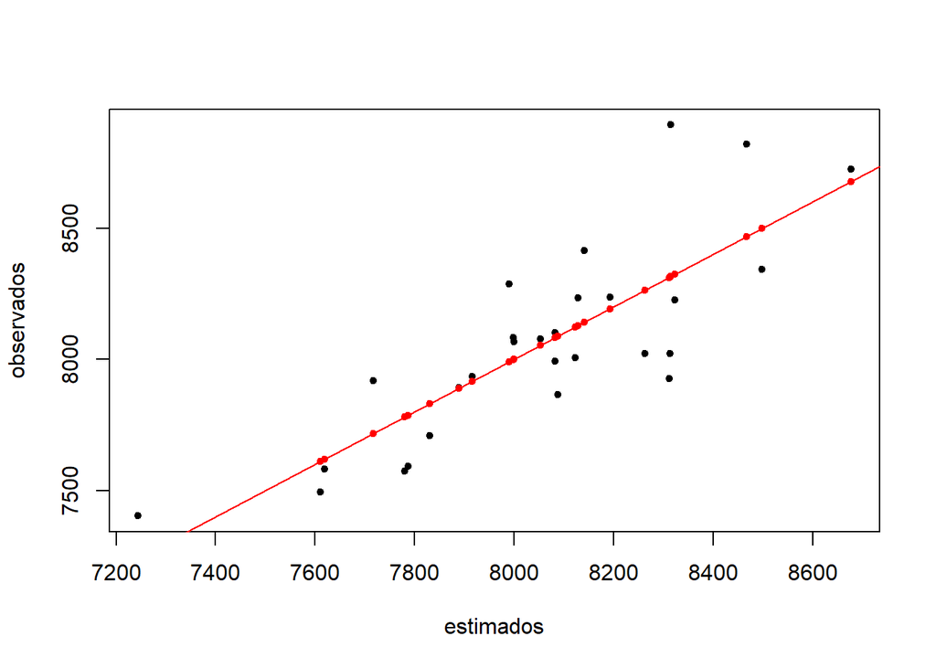

```r
mod_vel_graficos <- graficar_modelos(mod_vel)
mod_vel_graficos$estimados_observados()
```

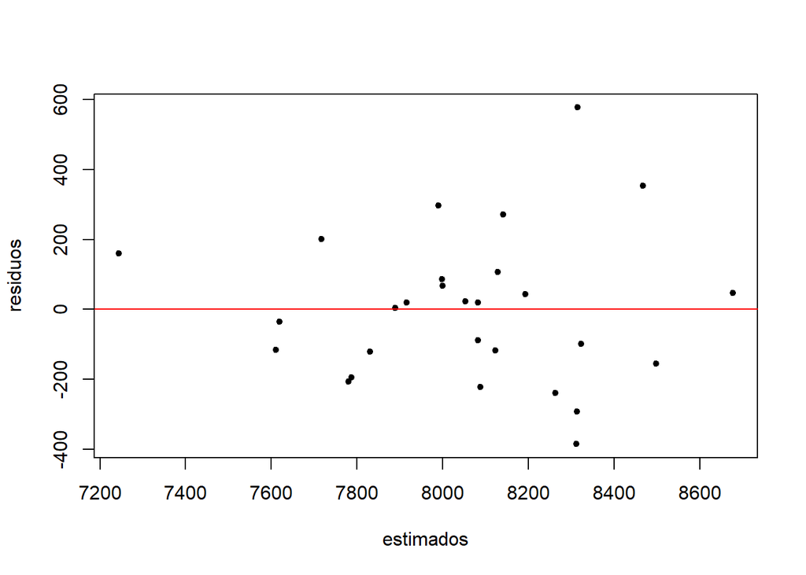

```r
mod_vel_graficos$estimados_residuos()
```

### 1.2 Modelar con los tres saltos

```r
mod_saltos <- lm(
  Points ~ Long.jump + High.jump + Pole.vault,
  data = Decathlon
)
summary(mod_saltos)
```

```
##
## Call:
## lm(formula = Points ~ Long.jump + High.jump + Pole.vault, data = Decathlon)
##
## Residuals:
##     Min      1Q  Median      3Q     Max
## -412.58 -112.84  -21.79  131.11  472.48
##
## Coefficients:
##             Estimate Std. Error t value Pr(>|t|)
## (Intercept)   -919.8     1113.6  -0.826 0.416956
## Long.jump      632.9      124.1   5.099 3.24e-05 ***
## High.jump     1791.4      451.7   3.966 0.000574 ***
## Pole.vault     175.9      137.4   1.280 0.212895
## ---
## Signif. codes:  0 '***' 0.001 '**' 0.01 '*' 0.05 '.' 0.1 ' ' 1
##
## Residual standard error: 195.6 on 24 degrees of freedom
## Multiple R-squared:  0.7549, Adjusted R-squared:  0.7243
## F-statistic: 24.64 on 3 and 24 DF,  p-value: 1.665e-07
```

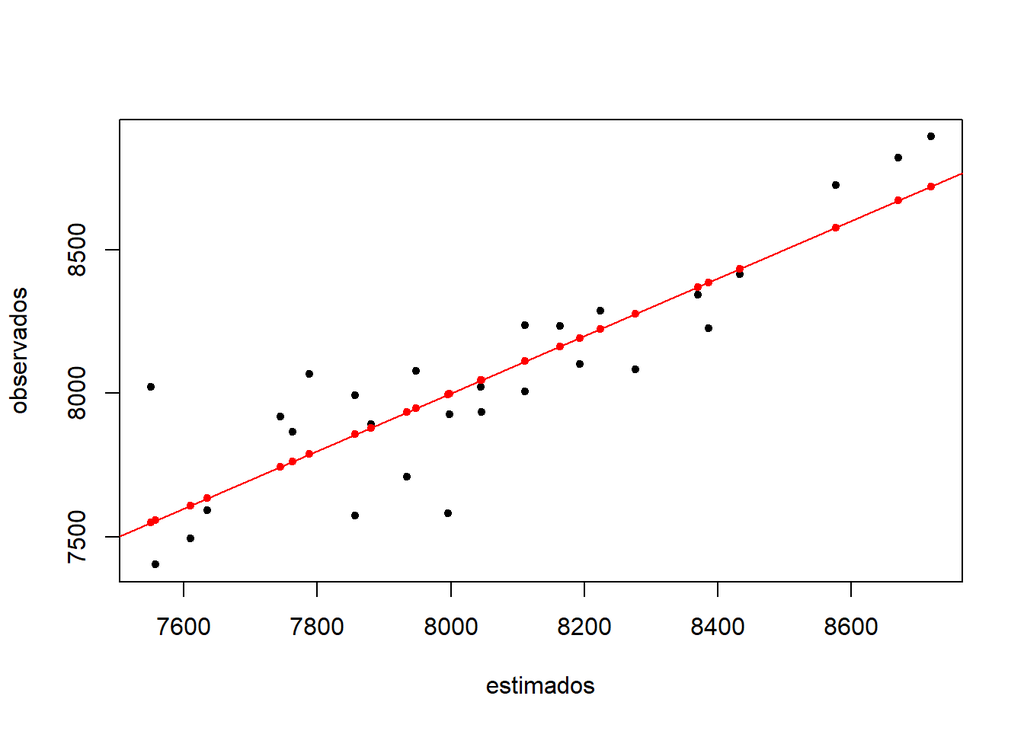

```r
mod_saltos_graficos <- graficar_modelos(mod_saltos)
mod_saltos_graficos$estimados_observados()
```

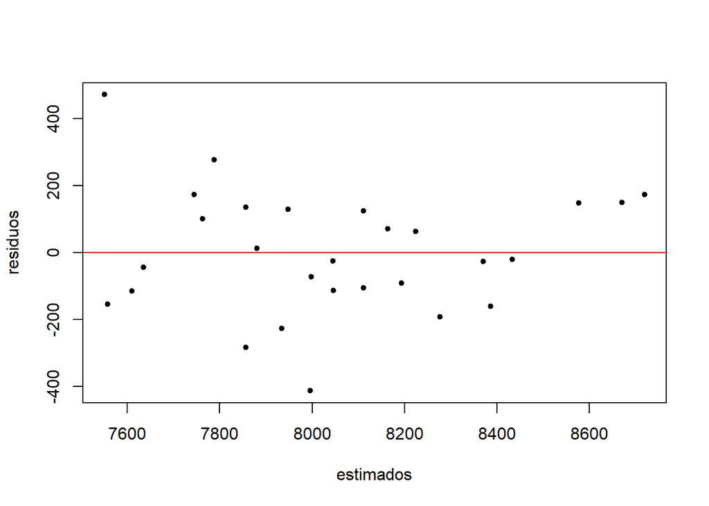

```r
mod_saltos_graficos$estimados_residuos()
```

### 1.3 Modelar con los tres lanzamientos

```r
mod_lanzamientos <- lm(
  Points ~ Discus + Javeline + Shot.put,
  data = Decathlon
)
summary(mod_lanzamientos)
```

```
##
## Call:
## lm(formula = Points ~ Discus + Javeline + Shot.put, data = Decathlon)
##
## Residuals:
##     Min      1Q  Median      3Q     Max
## -777.19 -137.44   20.18  206.08  387.86
##
## Coefficients:
##             Estimate Std. Error t value Pr(>|t|)
## (Intercept)  3547.75    1039.03   3.414  0.00228 **
## Discus         18.66      23.11   0.807  0.42731
## Javeline       16.11      12.38   1.301  0.20569
## Shot.put      186.40      93.25   1.999  0.05706 .
## ---
## Signif. codes:  0 '***' 0.001 '**' 0.01 '*' 0.05 '.' 0.1 ' ' 1
##
## Residual standard error: 295.7 on 24 degrees of freedom
## Multiple R-squared:  0.4401, Adjusted R-squared:  0.3702
## F-statistic: 6.289 on 3 and 24 DF,  p-value: 0.002654
```

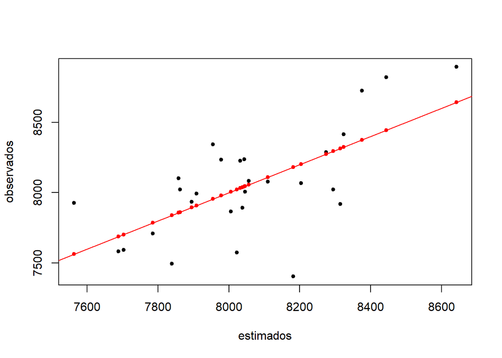

```r
mod_lanzamientos_graficos <- graficar_modelos(mod_lanzamientos)
mod_lanzamientos_graficos$estimados_observados()
```

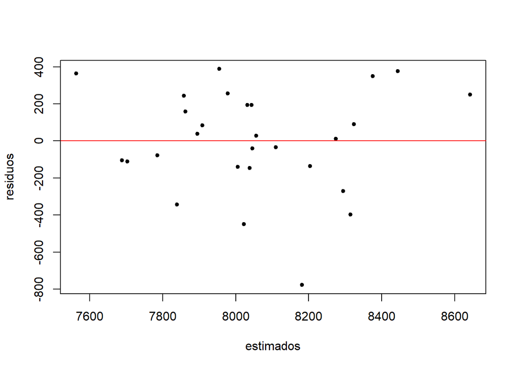

```r
mod_lanzamientos_graficos$estimados_residuos()
```

## 2 Pregunta 4: Evaluación de los modelos

```r
extraer_estadistica_f <- function(modelo) {
  return(summary(modelo)$fstatistic[1])
}

obtener_p_valor_de_estadistica_f <- function(modelo) {
  s <- summary(modelo)

  fval <- s$fstatistic["value"]
  df1 <- s$fstatistic["numdf"]
  df2 <- s$fstatistic["dendf"]

  return(pf(fval, df1, df2, lower.tail = FALSE))
}

extraer_info_t_student <- function(modelo) {
  df <- as.data.frame(summary(modelo)$coefficients)
  df <- df[-1, c(-1, -2)]

  df$es_significativo <- df[, 2] < 0.05
  return(df)
}
```

### 2.1 Modelo con las cuatro velocidades

Estadística F: 11.8642071

p-valor: 2.2416122^{-5}

Como el p-valor es mucho menor que 0.05, rechazamos la hipótesis nula. Esto implica que, **en grupo** (no necesariamente individualmente), el conjunto de las cuatro velocidades explica significativamente la varianza asociada a la variable `Points`.

### 2.2 Modelo con las cuatro velocidades

Estadística F: 11.8642071

p-valor: 2.2416122^{-5}

Como el p-valor es mucho menor que 0.05, rechazamos la hipótesis nula. Esto implica que, **en grupo** (no necesariamente individualmente), el conjunto de las cuatro velocidades explica significativamente la varianza asociada a la variable `Points`.

```r
extraer_info_t_student(mod_vel)
```

```
##                 t value   Pr(>|t|) es_significativo
## X100m        -2.0498960 0.05194374            FALSE
## X400m        -1.3486686 0.19057422            FALSE
## X1500m       -0.3584653 0.72326449            FALSE
## X110m.hurdle -1.9947822 0.05804863            FALSE
```

Note que para ninguna de las variables de velocidades podemos afirmar que tiene sentido en el modelo, como variable explicativa. Esto pues sus p valores respectivos asociados vía el test de los $\hat{\beta_i}$ no son menores que 0.05.

### 2.3 Modelo con las tres saltos

Estadística F: 24.6404597

p-valor: 1.6654522^{-7}

Como el p-valor es mucho menor que 0.05, rechazamos la hipótesis nula. Esto implica que el conjunto de los tres saltos explica significativamente la varianza asociada a la variable `Points`.

```r
extraer_info_t_student(mod_saltos)
```

```
##             t value     Pr(>|t|) es_significativo
## Long.jump  5.098551 3.238886e-05             TRUE
## High.jump  3.966220 5.738352e-04             TRUE
## Pole.vault 1.279668 2.128947e-01            FALSE
```

Note que, entre las variables `Long.jump`, `High.jump` y `Pole.vault`, solo para la variable `Pole.vault` no contamos con suficiente evidencia para afirmar que como variable explicativa tiene sentido en el modelo.

### 2.4 Modelo con las tres lanzamientos

Estadística F: 6.2894594

p-valor: 0.0026538

Como el p-valor es mucho menor que 0.05, rechazamos la hipótesis nula. Esto implica que el conjunto de los tres lanzamientos explica significativamente la varianza asociada a la variable `Points`.

```r
extraer_info_t_student(mod_lanzamientos)
```

```
##            t value   Pr(>|t|) es_significativo
## Discus   0.8074968 0.42731134            FALSE
## Javeline 1.3007547 0.20569388            FALSE
## Shot.put 1.9989130 0.05706494            FALSE
```

Note que para ninguna de las variables de lanzamientos podemos afirmar que tiene sentido en el modelo, como variable explicativa. Esto pues sus p valores respectivos asociados vía el test de los $\hat{\beta_i}$ no son menores que 0.05.

## 3 Pregunta 5: Selección del modelo vía residuo promedio

```r
calcular_rse <- function(modelo) {
  k <- length(modelo$coefficients) - 1
  SSE <- sum(modelo$residuals**2)
  num_obs <- length(modelo$residuals)

  return(sqrt(SSE/(num_obs - (1+k))))
}
```

```r
rse_modelos <- c(
  velocidades = calcular_rse(mod_vel),
  saltos = calcular_rse(mod_saltos),
  lanzamientos = calcular_rse(mod_lanzamientos)
)
rse_modelos
```

```
##  velocidades       saltos lanzamientos
##     230.6386     195.6387     295.6820
```

Considerando el residuo promedio, optaríamos por aquel modelo que presente un **menor** valor respectivo. En ese sentido particular, el mejor modelo entre los tres construídos es aquel cuyas varias explicativas son los tres tipos de saltos.

## 4 Preguntas 6 y 7: Modelos con transformaciones no triviales a los predictores

```r
mod_6_1 <- lm(
  Points ~ X100m + I(Javeline^2) + I(Shot.put * X400m),
  data = Decathlon
)
summary(mod_6_1)
```

```
##
## Call:
## lm(formula = Points ~ X100m + I(Javeline^2) + I(Shot.put * X400m),
##     data = Decathlon)
##
## Residuals:
##     Min      1Q  Median      3Q     Max
## -405.87 -152.48   20.91  125.97  357.30
##
## Coefficients:
##                       Estimate Std. Error t value Pr(>|t|)
## (Intercept)          1.881e+04  2.172e+03   8.661 7.53e-09 ***
## X100m               -1.121e+03  1.822e+02  -6.152 2.35e-06 ***
## I(Javeline^2)        2.391e-01  7.513e-02   3.182  0.00401 **
## I(Shot.put * X400m)  8.819e-01  1.058e+00   0.834  0.41264
## ---
## Signif. codes:  0 '***' 0.001 '**' 0.01 '*' 0.05 '.' 0.1 ' ' 1
##
## Residual standard error: 217.9 on 24 degrees of freedom
## Multiple R-squared:  0.6958, Adjusted R-squared:  0.6578
## F-statistic:  18.3 on 3 and 24 DF,  p-value: 2.142e-06
```

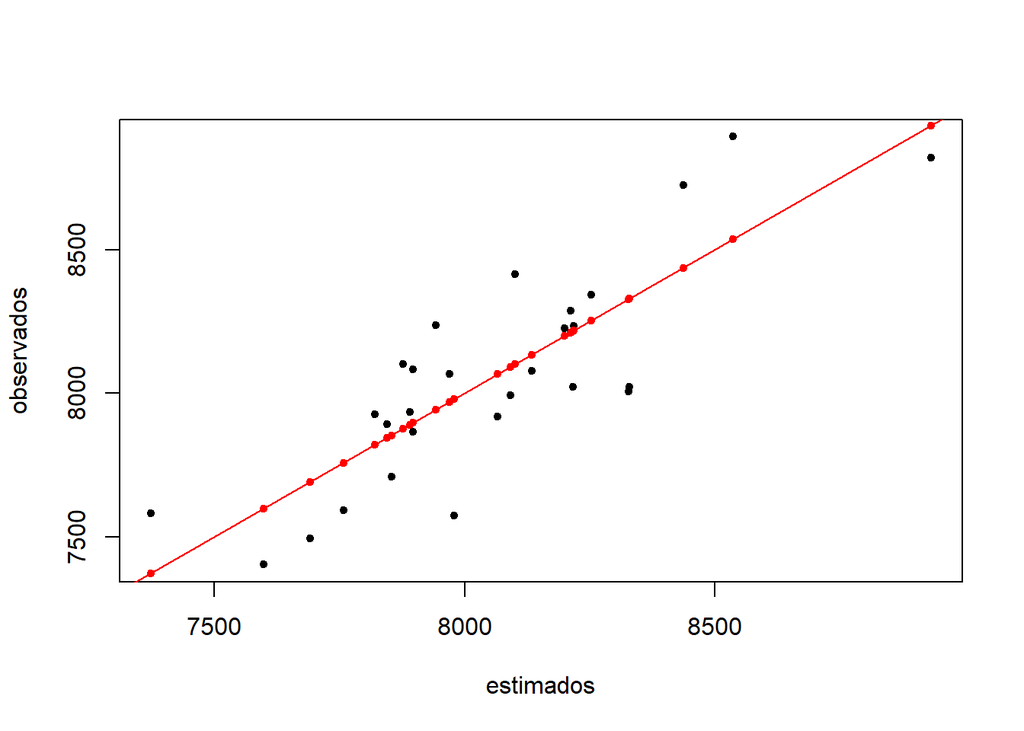

```r
mod_6_1_graficos <- graficar_modelos(mod_6_1)
mod_6_1_graficos$estimados_observados()
```

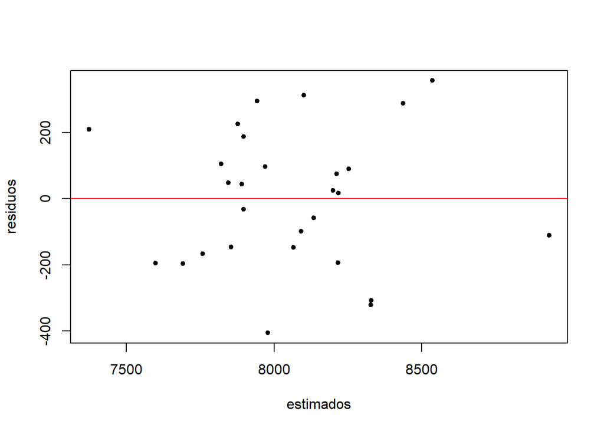

```r
mod_6_1_graficos$estimados_residuos()
```

```r
extraer_estadistica_f(mod_6_1)
```

```
##    value
## 18.30252
```

```r
obtener_p_valor_de_estadistica_f(mod_6_1)
```

```
##        value
## 2.141674e-06
```

```r
extraer_info_t_student(mod_6_1)
```

```
##                        t value     Pr(>|t|) es_significativo
## X100m               -6.1518220 2.348505e-06             TRUE
## I(Javeline^2)        3.1821633 4.010032e-03             TRUE
## I(Shot.put * X400m)  0.8337559 4.126402e-01            FALSE
```

```r
calcular_rse(mod_6_1)
```

```
## [1] 217.9386
```

Nótese que para **este** nuevo modelo planteado, **sí** resultan tener sentido (p valor menor que 0.05 para el test t-student) la información proporcionada por las variales `X100m` y `Javeline`, comparado a su utilidad en los modelos previamente analizados.

```r
mod_6_2 <- lm(
  Points ~ I(X1500m + Discus + X1500m*Discus + log(Long.jump)),
  data = Decathlon
)
summary(mod_6_2)
```

```
##
## Call:
## lm(formula = Points ~ I(X1500m + Discus + X1500m * Discus + log(Long.jump)),
##     data = Decathlon)
##
## Residuals:
##     Min      1Q  Median      3Q     Max
## -829.36 -148.84   30.85  232.08  727.19
##
## Coefficients:
##                                                        Estimate Std. Error t value Pr(>|t|)
## (Intercept)                                           6.960e+03  7.761e+02   8.968 1.95e-09 ***
## I(X1500m + Discus + X1500m * Discus + log(Long.jump)) 8.627e-02  6.112e-02   1.412     0.17
## ---
## Signif. codes:  0 '***' 0.001 '**' 0.01 '*' 0.05 '.' 0.1 ' ' 1
##
## Residual standard error: 365.9 on 26 degrees of freedom
## Multiple R-squared:  0.07118,    Adjusted R-squared:  0.03545
## F-statistic: 1.992 on 1 and 26 DF,  p-value: 0.1699
```

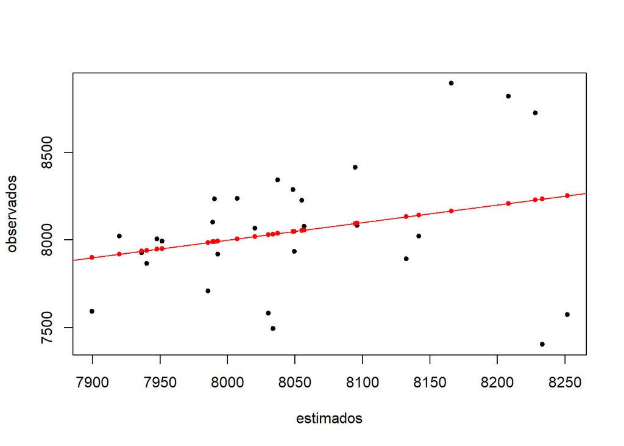

```r
mod_6_2_graficos <- graficar_modelos(mod_6_2)
mod_6_2_graficos$estimados_observados()
```

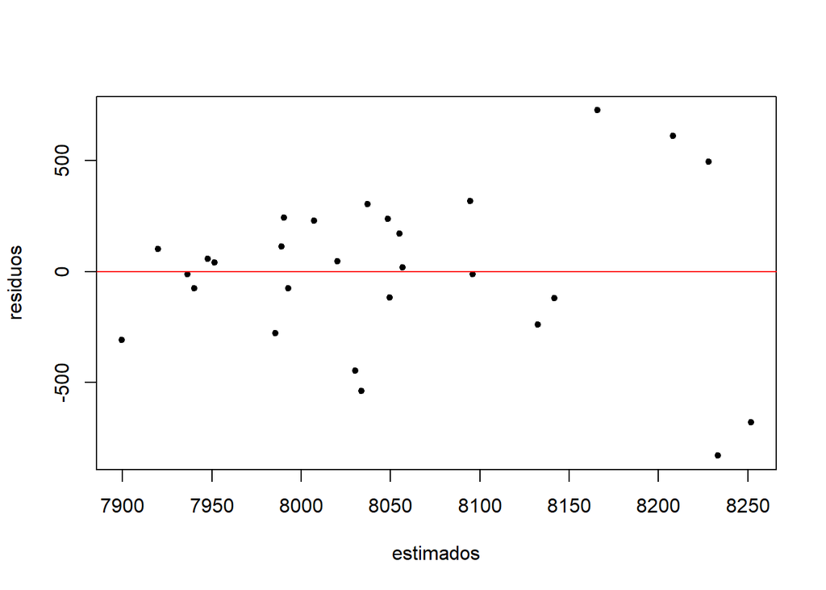

```r
mod_6_2_graficos$estimados_residuos()
```

```r
extraer_estadistica_f(mod_6_2)
```

```
##    value
## 1.992445
```

```r
obtener_p_valor_de_estadistica_f(mod_6_2)
```

```
##     value
## 0.1699413
```

```r
extraer_info_t_student(mod_6_2)
```

```
##                                                       t value  Pr(>|t|) es_significativo
## I(X1500m + Discus + X1500m * Discus + log(Long.jump)) 1.41154 0.1699413            FALSE
```

```r
calcular_rse(mod_6_2)
```

```
## [1] 365.909
```

Nótese que en este modelo con intercepto y un solo regresor, los tests vía estadística F y t-student producen la misma conclusión: El regresor planteado/construido **no** tiene sentido como variable explicativa para la variable `Points`.